# 4323 Final Project- College Basketball Dataset

Ryan Nguyen and Justin George

2023-04-25

# Background on our Dataset

My project as a whole aims to use supervised learning to predict the stage at which a given college basketball team will be eliminated from the NCAA March Madness Tournament. The response variable is the categorical variable POSTSEASON, which represents the stage which the team was eliminated or where their season ended. We plan to use K-nearest neighbor classifier, support vector machines, and other categorical supervised learning algorithms to develop the classification model.

# Ryan: Conducting Principal Component Analysis (PCA)

Since we are using a large dataset with all the stats on college basketball teams during one season, and the high dimensionality of our data, we want to make sure that our PCA does its best to determine which variables account for the most variance to find the ones that are most significant. This will help predict our responses most accurately.

Here are some key points to note:  
- PCA will come in use for other two models we are running  
- PCA will be tested with and without effect  
- Some models with complete dataset; some models with limited amount

# Slide with R Output

[output not shown]

[output cut: 7353 more lines]

# Slide with Continued R Output

```
## Importance of components:
##                           PC1    PC2     PC3     PC4     PC5     PC6     PC7
## Standard deviation     2.7041 1.8136 1.19206 1.05047 0.98830 0.93461 0.88664
## Proportion of Variance 0.3849 0.1731 0.07479 0.05808 0.05141 0.04597 0.04138
## Cumulative Proportion  0.3849 0.5580 0.63276 0.69084 0.74225 0.78822 0.82960
##                            PC8     PC9    PC10    PC11    PC12    PC13    PC14
## Standard deviation     0.85214 0.76461 0.74007 0.69434 0.65444 0.53298 0.33169
## Proportion of Variance 0.03822 0.03077 0.02883 0.02537 0.02254 0.01495 0.00579
## Cumulative Proportion  0.86781 0.89858 0.92741 0.95278 0.97533 0.99028 0.99607
##                           PC15    PC16    PC17    PC18    PC19
## Standard deviation     0.18829 0.14015 0.11468 0.06288 0.05013
## Proportion of Variance 0.00187 0.00103 0.00069 0.00021 0.00013
## Cumulative Proportion  0.99793 0.99897 0.99966 0.99987 1.00000
```

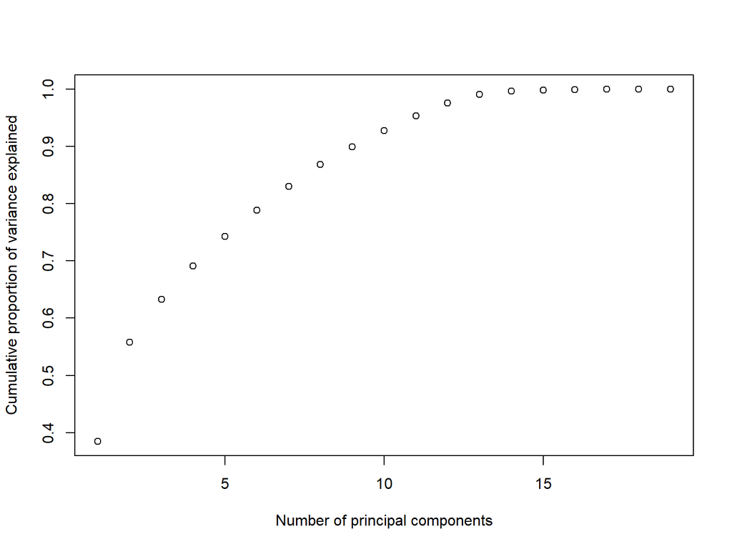

[output not shown]

[output cut: 2441 more lines]